# Week 6: Probability Theory

Gabriel Vance

April 15, 2025

# Imports

```r
library(ggplot2)
library(dplyr)
library(tidyr)
```

# A six-sided die is rolled repeatedly. What is the expected value average as the die is rolled more and more? The expected value for a single roll is 1+2+3+4+5+6 / 6 = 3.5. What’s wrong with the answer, just in logical terms? Create this in R (i.e., simulate many rolls and visualize the results).

```r
rolls <- 10000 # number of rolls
die_rolls <- sample(1:6, rolls, replace = TRUE) # simulate rolling a die 10,000 times
die_rolls_df <- data.frame(roll = die_rolls) # create a dataframe for visualization
# Die have whole numbers, such as 1, 2, 3. Just because the average is 3.5 does not mean you will roll a 3.5 because 3.5 is not the side of a die. The average value will approach 3.5 as the number of rolls increases, but it will never actually be 3.5.

mean(die_rolls_df$roll) # for example, this was 3.48
```

```
## [1] 3.4784
```

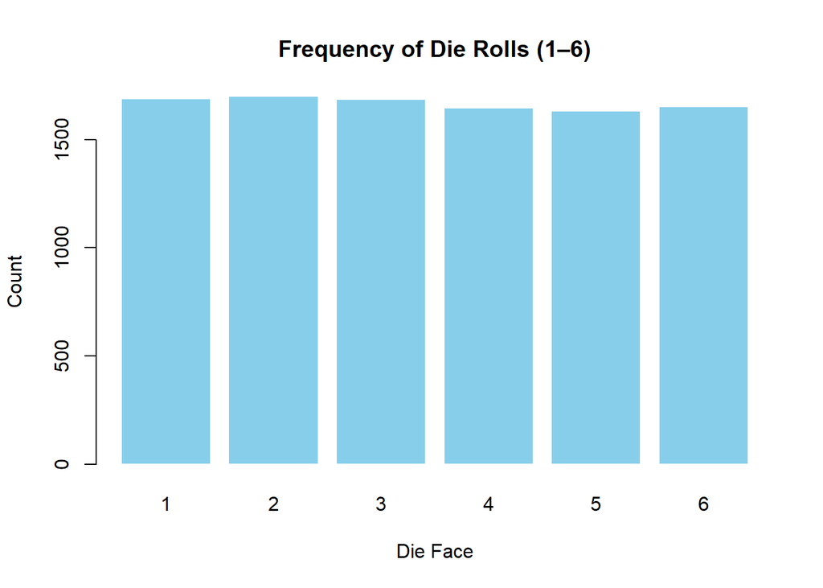

```r
roll_counts <- table(die_rolls_df$roll)
barplot(roll_counts,
  main = "Frequency of Die Rolls (1–6)",
  xlab = "Die Face",
  ylab = "Count",
  col = "skyblue",
  border = "white"
)
```

# A box contains 30 red balls and 15 green balls. A ball is drawn from the box, and the color is written down. The ball is then returned to the box, and the process is repeated. What is the expected proportion of red balls drawn as the number of draws increases? Create this in R (i.e., simulate the draws from the box and visualize the results).

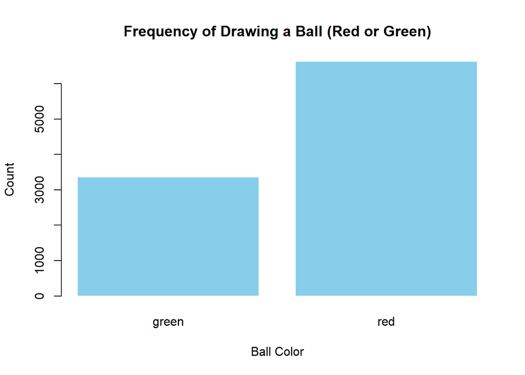

```r
balls_drawn <- 100000 # number of balls drawn
balls <- sample(c("red", "green"), rolls, replace = TRUE, prob = c(2 / 3, 1 / 3))
balls_df <- data.frame(draw = balls) # create a dataframe for visualization

draw_counts <- table(balls_df$draw)


barplot(draw_counts,
  main = "Frequency of Drawing a Ball (Red or Green)",
  xlab = "Ball Color",
  ylab = "Count",
  col = "skyblue",
  border = "white"
)
```

```r
theoretical_red_to_green_ratio <- 30 / 15 # 2:1
actual_red_to_green_ratio <- draw_counts["red"] / draw_counts["green"]

cat(paste(
  "Expected ratio of red to green balls:", theoretical_red_to_green_ratio,
  "\nActual ratio of red to green balls:", round(actual_red_to_green_ratio, 2)
))
```

```
## Expected ratio of red to green balls: 2
## Actual ratio of red to green balls: 1.97
```

# Do Exercise 1 from the text (in Chapter 9). You can use the author’s code, and it is strongly suggested that instead of copying/pasting, you re-write the code. Explain each line in the code both in programming (i.e., what the R is doing) and statistics terms.

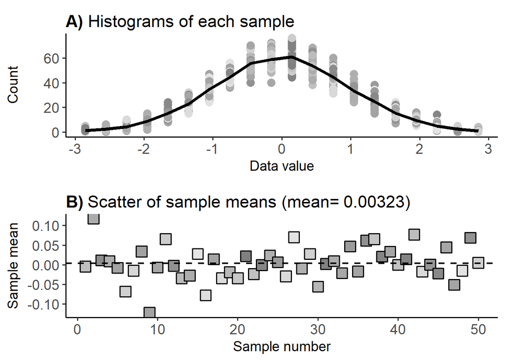

```r
library(ggplot2) # plotting
library(cowplot) # plot_grid()
library(emg) # remg() : exGaussian distribution
library(pracma) # logspace()
library(tidyr) # gather()

theme_set(theme_classic(base_size = 14))
options(scipen = 999)

# The main goal of the exercise is to explore LLN, abd wgt sanoke neabs gave kess variabilkity than indivuial samples.


N <- 500
nSamples <- 50
kHistBins <- 20

# bins for histograms
edges <- seq(-3, 3, length.out = kHistBins + 1)

# declare matrices
allHistY <- matrix(0, nrow = nSamples, ncol = kHistBins)
allMeans <- rep(0, nSamples)
ldatall <- data.frame(mids = NULL, Count = NULL)


for (sampi in 1:nSamples) {
  # create data (same parameters in all simulations!)
  data <- rnorm(N, mean = 0, sd = 1)

  # histograms
  histY <- hist(data[abs(data) <= 3.0], breaks = edges, plot = FALSE)
  allHistY[sampi, ] <- histY$counts

  ldat <- data.frame(mids = histY$mids, Count = histY$counts)

  # get means
  allMeans[sampi] <- mean(data)
  ldatall <- rbind(ldatall, ldat)
}

# plots
titleA <- expression(paste(bold("A)"), " Histograms of each sample"))
titleB <- bquote(bold("B)") ~ "Scatter of sample means (mean=" ~ .(sprintf("%.3g", mean(allMeans))) * ")")

c <- runif(50, min = 0.5, max = 0.9)

ggp1 <- ggplot(data = ldatall) +
  aes(x = mids, y = Count) +
  theme(legend.position = "none") +
  geom_point(colour = rgb(rep(c, 20), rep(c, 20), rep(c, 20)), size = 3.5) +
  # plot the average histogram
  geom_line(stat = "summary", fun = "mean", linewidth = 1.5) +
  labs(x = "Data value", y = "Count", title = titleA) +
  theme(axis.text = element_text(size = 14), plot.title = element_text(vjust = -1))


# plot the means, and the mean of the means


ggp2 <- ggplot() +
  geom_point(aes(x = 1:50, y = allMeans), shape = 22, size = 5, fill = rgb(c, c, c), stroke = 1.0) +
  geom_hline(yintercept = mean(allMeans), linetype = 2, linewidth = .8) +
  labs(x = "Sample number", y = "Sample mean", title = titleB) +
  theme(legend.position = "none", axis.text = element_text(size = 14), plot.title = element_text(vjust = -1))

# setup figure
plot_grid(ggp1, ggp2, ncol = 1, align = "v")
```

```r
# save the figure as 'png'
ggsave("sample_exampleWithRandom.png", device = "png", width = 7, height = 6)
```